# Project Python Foundations: FoodHub Data Analysis

**Marks: 60**

### Context

The number of restaurants in New York is increasing day by day. Lots of students and busy professionals rely on those restaurants due to their hectic lifestyles. Online food delivery service is a great option for them. It provides them with good food from their favorite restaurants. A food aggregator company FoodHub offers access to multiple restaurants through a single smartphone app.

The app allows the restaurants to receive a direct online order from a customer. The app assigns a delivery person from the company to pick up the order after it is confirmed by the restaurant. The delivery person then uses the map to reach the restaurant and waits for the food package. Once the food package is handed over to the delivery person, he/she confirms the pick-up in the app and travels to the customer's location to deliver the food. The delivery person confirms the drop-off in the app after delivering the food package to the customer. The customer can rate the order in the app. The food aggregator earns money by collecting a fixed margin of the delivery order from the restaurants.

### Objective

The food aggregator company has stored the data of the different orders made by the registered customers in their online portal. They want to analyze the data to get a fair idea about the demand of different restaurants which will help them in enhancing their customer experience. Suppose you are hired as a Data Scientist in this company and the Data Science team has shared some of the key questions that need to be answered. Perform the data analysis to find answers to these questions that will help the company to improve the business.

### Data Description

The data contains the different data related to a food order. The detailed data dictionary is given below.

### Data Dictionary

- order_id: Unique ID of the order
- customer_id: ID of the customer who ordered the food
- restaurant_name: Name of the restaurant
- cuisine_type: Cuisine ordered by the customer
- cost: Cost of the order
- day_of_the_week: Indicates whether the order is placed on a weekday or weekend (The weekday is from Monday to Friday and the weekend is Saturday and Sunday)
- rating: Rating given by the customer out of 5
- food_preparation_time: Time (in minutes) taken by the restaurant to prepare the food. This is calculated by taking the difference between the timestamps of the restaurant's order confirmation and the delivery person's pick-up confirmation.
- delivery_time: Time (in minutes) taken by the delivery person to deliver the food package. This is calculated by taking the difference between the timestamps of the delivery person's pick-up confirmation and drop-off information

### Let us start by importing the required libraries

```python
# import libraries for data manipulation
import numpy as np
import pandas as pd

# import libraries for data visualization
import matplotlib.pyplot as plt
import seaborn as sns
```

### Understanding the structure of the data

```python
# uncomment and run the following lines for Google Colab
# from google.colab import drive
# drive.mount('/content/drive')
```

```python
# read the data
df = pd.read_csv('foodhub_order.csv')
# Replace 'Not given' with NaN and convert the column to numeric
df['rating'] = pd.to_numeric(df['rating'], errors='coerce')
# returns the first 5 rows
df.head()
```

|  | order_id | customer_id | restaurant_name | cuisine_type | cost_of_the_order | day_of_the_week | rating | food_preparation_time | delivery_time |
| --- | --- | --- | --- | --- | --- | --- | --- | --- | --- |
| 0 | 1477147 | 337525 | Hangawi | Korean | 30.75 | Weekend | NaN | 25 | 20 |
| 1 | 1477685 | 358141 | Blue Ribbon Sushi Izakaya | Japanese | 12.08 | Weekend | NaN | 25 | 23 |
| 2 | 1477070 | 66393 | Cafe Habana | Mexican | 12.23 | Weekday | 5.0 | 23 | 28 |
| 3 | 1477334 | 106968 | Blue Ribbon Fried Chicken | American | 29.20 | Weekend | 3.0 | 25 | 15 |
| 4 | 1478249 | 76942 | Dirty Bird to Go | American | 11.59 | Weekday | 4.0 | 25 | 24 |

#### Observations:

The DataFrame has 9 columns as mentioned in the Data Dictionary. Data in each row corresponds to the order placed by a customer.

### **Question 1:** How many rows and columns are present in the data? [0.5 mark]

```python
# using the shape attribute to determine the rows and columns of the dataframe.
df_rows, df_columns = df.shape
print(f"The data has {df_rows} rows.")
print(f"The data has {df_columns} columns.")
```

```
The data has 1898 rows.
The data has 9 columns.
```

#### Observations:

My observations can be viewed from my print statements.

### **Question 2:** What are the datatypes of the different columns in the dataset? (The info() function can be used) [0.5 mark]

```python
# Use info() to print a concise summary of the DataFrame
df.info()
```

```
<class 'pandas.core.frame.DataFrame'>
RangeIndex: 1898 entries, 0 to 1897
Data columns (total 9 columns):
 #   Column                 Non-Null Count  Dtype
---  ------                 --------------  -----
 0   order_id               1898 non-null   int64
 1   customer_id            1898 non-null   int64
 2   restaurant_name        1898 non-null   object
 3   cuisine_type           1898 non-null   object
 4   cost_of_the_order      1898 non-null   float64
 5   day_of_the_week        1898 non-null   object
 6   rating                 1162 non-null   float64
 7   food_preparation_time  1898 non-null   int64
 8   delivery_time          1898 non-null   int64
dtypes: float64(2), int64(4), object(3)
memory usage: 133.6+ KB
```

#### Observations:

The following columns are integers: order_id, customer_id, food_preparation_time, and delivery_time

Columns that are floats: cost_of_the_order

I changed the 'rating' column to float so that I can more easily visualize the data in the column.

### **Question 3:** Are there any missing values in the data? If yes, treat them using an appropriate method. [1 mark]

```python
# checks for missing values in the entire dataframe
missing_values = df.isnull()
# sums the number of missing values in the dataframe for each column
missing_count = missing_values.sum()
#printing the summation of missing values for each column.
print(missing_count)
```

```
order_id                   0
customer_id                0
restaurant_name            0
cuisine_type               0
cost_of_the_order          0
day_of_the_week            0
rating                   736
food_preparation_time      0
delivery_time              0
dtype: int64
```

### **Question 4:** Check the statistical summary of the data. What is the minimum, average, and maximum time it takes for food to be prepared once an order is placed? [2 marks]

```python
# storing the statistical summary of df as a variable
df_summary = df.describe()
print(df_summary)
```

```
           order_id    customer_id  cost_of_the_order       rating  \
count  1.898000e+03    1898.000000        1898.000000  1162.000000
mean   1.477496e+06  171168.478398          16.498851     4.344234
std    5.480497e+02  113698.139743           7.483812     0.741478
min    1.476547e+06    1311.000000           4.470000     3.000000
25%    1.477021e+06   77787.750000          12.080000     4.000000
50%    1.477496e+06  128600.000000          14.140000     5.000000
75%    1.477970e+06  270525.000000          22.297500     5.000000
max    1.478444e+06  405334.000000          35.410000     5.000000

       food_preparation_time  delivery_time
count            1898.000000    1898.000000
mean               27.371970      24.161749
std                 4.632481       4.972637
min                20.000000      15.000000
25%                23.000000      20.000000
50%                27.000000      25.000000
75%                31.000000      28.000000
max                35.000000      33.000000
```

#### Observations:

Times for food to be prepared once order is placed: minimimum: 20 minutes average: 27.37197 minutes (or 27 minutes and 22.32 seconds) maximum: 35 minutes

### **Question 5:** How many orders are not rated? [1 mark]

```python
# determining rows of column rating where there is no rating.
unrated_orders = df[df['rating'].isnull()]
print("Number of UNRATED orders by cuisine type:")
print(unrated_orders.groupby('cuisine_type')['order_id'].count())
print("\nTotal count of UNRATED orders:")
print(len(unrated_orders))

rated_orders = df[df['rating'] != 'Not given']
print("\nNumber of RATED orders by cuisine type:")
print(rated_orders.groupby('cuisine_type')['order_id'].count())
print("\nTotal count of RATED orders:")
print(len(rated_orders))
```

```
Number of UNRATED orders by cuisine type:
cuisine_type
American          216
Chinese            82
French              8
Indian             23
Italian           126
Japanese          197
Korean              4
Mediterranean      14
Mexican            29
Middle Eastern     15
Southern            4
Spanish             6
Thai               10
Vietnamese          2
Name: order_id, dtype: int64

Total count of UNRATED orders:
736

Number of RATED orders by cuisine type:
cuisine_type
American          584
Chinese           215
French             18
Indian             73
Italian           298
Japanese          470
Korean             13
Mediterranean      46
Mexican            77
Middle Eastern     49
Southern           17
Spanish            12
Thai               19
Vietnamese          7
Name: order_id, dtype: int64

Total count of RATED orders:
1898
```

#### Observations:

There are 736 total orders that are not rated. The cuisine with the highest number of unrated orders is American. Approximately 38.8% of the orders are not rated in the dataset. 1162 orders do have a rating.

### Exploratory Data Analysis (EDA)

### **Question 6:** Explore all the variables and provide observations on their distributions. (Generally, histograms, boxplots, countplots, etc. are used for univariate exploration.) [9 marks]

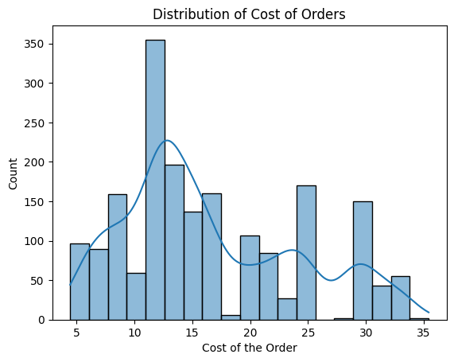

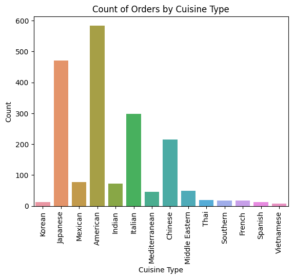

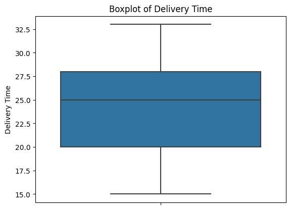

[figure not shown]

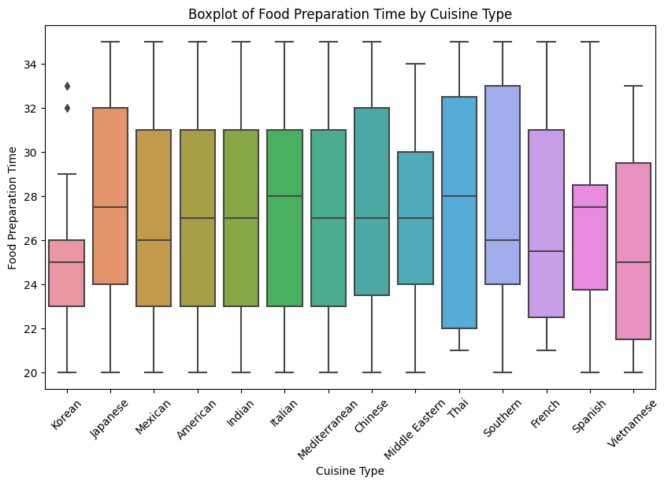

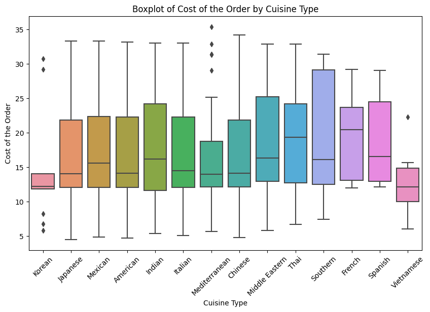

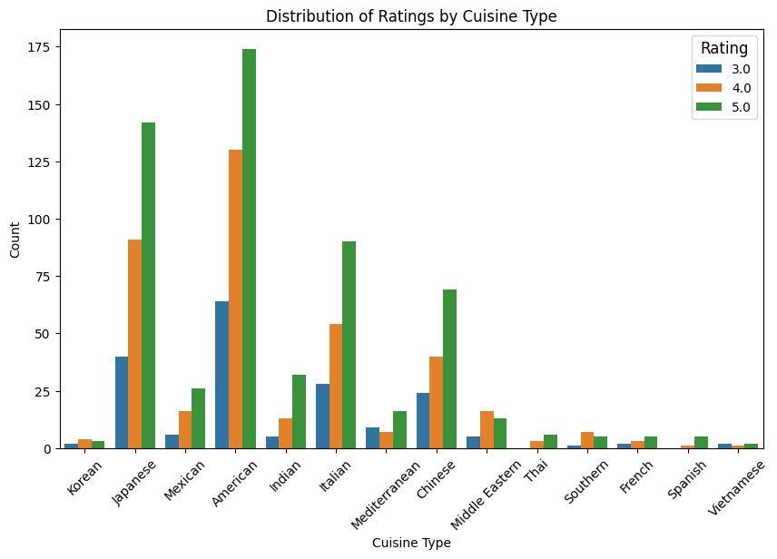

```python
# Creating a histogram to visualize distribution of cost of order based on counts in the data.
sns.histplot(df['cost_of_the_order'], kde=True)
plt.xlabel('Cost of the Order')
plt.title('Distribution of Cost of Orders')
plt.show()

# Using a count plot to display count of cuisine types
sns.countplot(data=df, x='cuisine_type')
plt.xlabel('Cuisine Type')
plt.ylabel('Count')
plt.title('Count of Orders by Cuisine Type')
plt.xticks(rotation=90)
plt.show()

# boxplot for visualizing delivery times
sns.boxplot(data=df, y='delivery_time')
plt.ylabel('Delivery Time')
plt.title('Boxplot of Delivery Time')
plt.show()

# boxplot for visualizing food preparation times
sns.boxplot(data=df, y='food_preparation_time')
plt.ylabel('Food Preparation Time')
plt.title('Boxplot of Delivery Time')
plt.show()

# Create boxplots visualizing the differences in food preparation time for each cuisine type.
plt.figure(figsize=(10, 6))  # Adjust the figure size if needed
sns.boxplot(data=df, x='cuisine_type', y='food_preparation_time')
plt.xlabel('Cuisine Type')
plt.ylabel('Food Preparation Time')
plt.title('Boxplot of Food Preparation Time by Cuisine Type')
plt.xticks(rotation=45)  # Rotate x-axis labels for better readability
plt.show()

# Create boxplots visualizing the differences in cost of orders for each cuisine type.
plt.figure(figsize=(10, 6))  # Adjust the figure size if needed
sns.boxplot(data=df, x='cuisine_type', y='cost_of_the_order')
plt.xlabel('Cuisine Type')
plt.ylabel('Cost of the Order')
plt.title('Boxplot of Cost of the Order by Cuisine Type')
plt.xticks(rotation=45)
plt.show()

# Create a countplot for rating
plt.figure(figsize=(10, 6))  # Adjust the figure size if needed
sns.countplot(data=df, x='cuisine_type', hue='rating')
plt.xlabel('Cuisine Type')
plt.ylabel('Count')
plt.title('Distribution of Ratings by Cuisine Type')
plt.xticks(rotation=45)  # Rotate x-axis labels for better readability
plt.legend(title='Rating', title_fontsize='12')
plt.show()
```

It appears that the distribution of cost of orders is right skewed, with the large concentration of orders being around 10-15$.

### **Question 7**: Which are the top 5 restaurants in terms of the number of orders received? [1 mark]

```python
# Grouping the restaurants by count of orders.
restaurant_orders = df['restaurant_name'].value_counts()
top_5_restaurants = restaurant_orders.head(5)
print("Top 5 restaurants by number of orders:")
print(top_5_restaurants)
```

```
Top 5 restaurants by number of orders:
Shake Shack                  219
The Meatball Shop            132
Blue Ribbon Sushi            119
Blue Ribbon Fried Chicken     96
Parm                          68
Name: restaurant_name, dtype: int64
```

#### Observations:

The top 5 restauarants in terms of orders received are Shake Shack (219 orders), The Meatball Shop(132 orders), Blue Ribbon Sushi(119 orders), Blue Ribbon Fried Chicken (96 Orders), and Parm (68 Orders).

### **Question 8**: Which is the most popular cuisine on weekends? [1 mark]

```python
# Filter the DataFrame to include only orders placed on weekends
weekend_orders = df[df['day_of_the_week'].isin(['Weekend'])]

# Find the top 5 cuisine orders on weekends
top_cuisine_orders = weekend_orders['cuisine_type'].value_counts().head(5)

# Print the details of the top 5 cuisine orders on weekends
print("Top 5 cuisine orders on the weekend:")
for cuisine, count in top_cuisine_orders.items():
    print(f"Cuisine: {cuisine}, Orders: {count}")
```

```
Top 5 cuisine orders on the weekend:
Cuisine: American, Orders: 415
Cuisine: Japanese, Orders: 335
Cuisine: Italian, Orders: 207
Cuisine: Chinese, Orders: 163
Cuisine: Mexican, Orders: 53
```

#### Observations:

The most popular cuisine on the weekdns is American.

### **Question 9**: What percentage of the orders cost more than 20 dollars? [2 marks]

```python
# Filtering the DataFrame to include only orders with a cost greater than $20
expensive_orders = df[df['cost_of_the_order'] > 20]

# Calculating the percentage of expensive orders relative to the total number of orders
count_expensive_orders = len(expensive_orders)
percentage_expensive_orders = (len(expensive_orders) / len(df)) * 100

# Print the percentage and count of orders greater than $20
print(f"The count of orders costing more than $20 is: {count_expensive_orders}")
print(f"The percentage of orders costing more than $20 is: {percentage_expensive_orders:.2f}%")
```

```
The count of orders costing more than $20 is: 555
The percentage of orders costing more than $20 is: 29.24%
```

#### Observations:

The observations can be viewed in my print statements.

### **Question 10**: What is the mean order delivery time? [1 mark]

```python
# Calculate the mean order delivery time
mean_delivery_time = df['delivery_time'].mean()

# Print the mean delivery time
print(f"The mean order delivery time is: {mean_delivery_time:.2f} minutes")
```

```
The mean order delivery time is: 24.16 minutes
```

#### Observations:

The mean order delivery time is 24.16 minutes. This matches my findings from question 4.

### **Question 11:** The company has decided to give 20% discount vouchers to the top 3 most frequent customers. Find the IDs of these customers and the number of orders they placed. [1 mark]

```python
# Finding the top 3 most frequent customers
top_customers = df['customer_id'].value_counts().head(3)

# Print the customer IDs and the number of orders they placed
print("Top 3 most frequent customers:")
for customer_id, order_count in top_customers.items():
    print(f"Customer ID: {customer_id}, Number of Orders: {order_count}")
```

```
Top 3 most frequent customers:
Customer ID: 52832, Number of Orders: 13
Customer ID: 47440, Number of Orders: 10
Customer ID: 83287, Number of Orders: 9
```

#### Observations:

### **Question 12**: Perform a multivariate analysis to explore relationships between the important variables in the dataset. (It is a good idea to explore relations between numerical variables as well as relations between numerical and categorical variables) [10 marks]

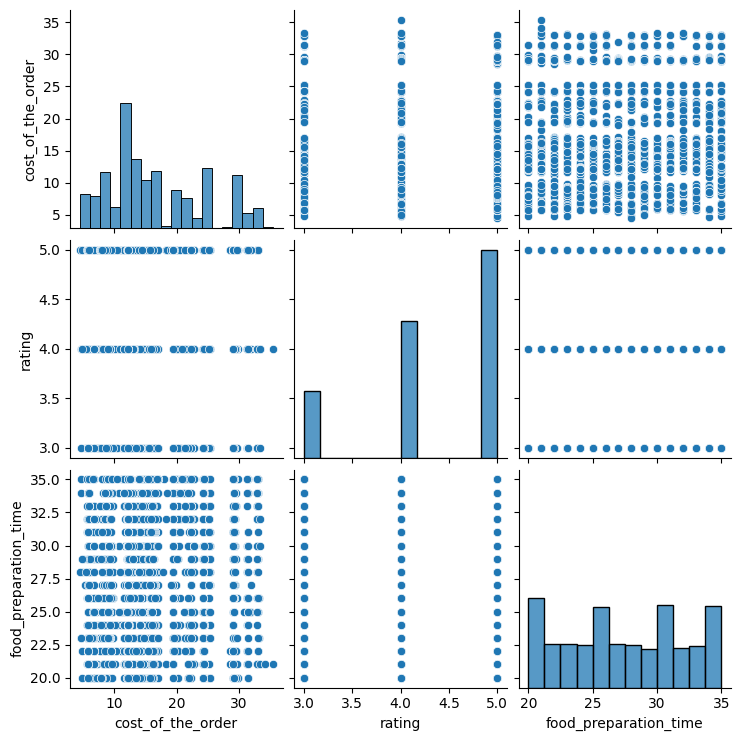

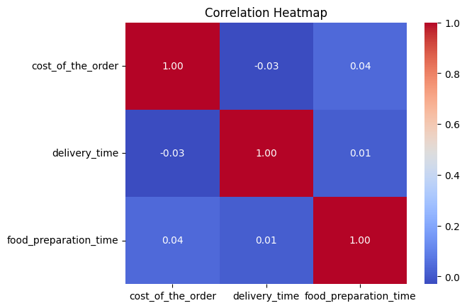

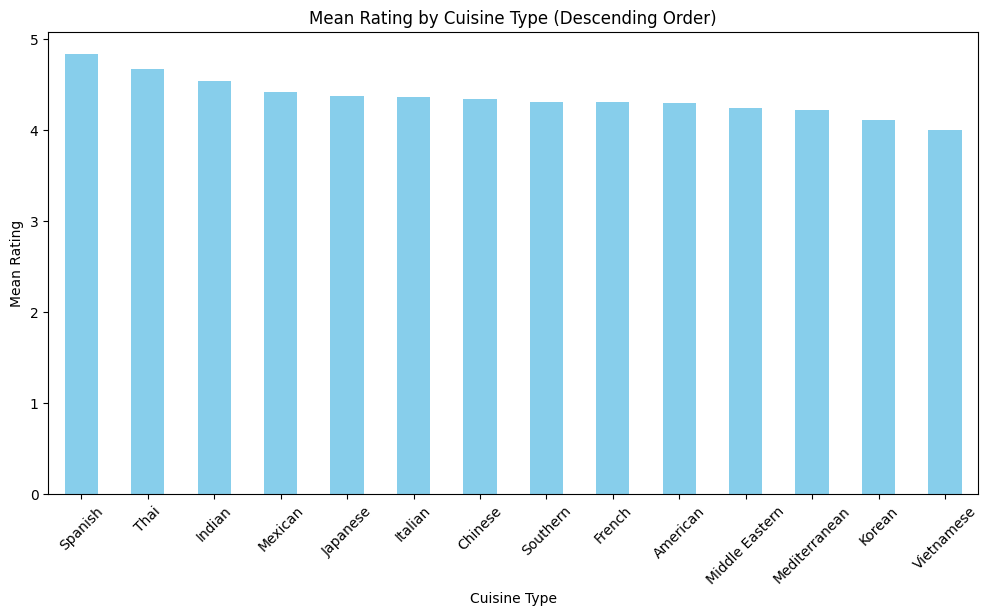

```python
sns.pairplot(df, vars=["cost_of_the_order", "rating", "food_preparation_time"])
plt.show()

# Calculate the correlation matrix
correlation_matrix = df[["cost_of_the_order", "delivery_time", "food_preparation_time"]].corr()

# Create a heatmap to visualize the correlations
sns.heatmap(correlation_matrix, annot=True, cmap="coolwarm", fmt=".2f")
plt.title("Correlation Heatmap")
plt.show()


# Calculate the mean rating for each cuisine type and sort in descending order
mean_rating_by_cuisine = df.groupby('cuisine_type')['rating'].mean().sort_values(ascending=False)

# Create a bar graph for mean ratings by cuisine type
plt.figure(figsize=(12, 6))
mean_rating_by_cuisine.plot(kind='bar', color='skyblue')
plt.title('Mean Rating by Cuisine Type (Descending Order)')
plt.xlabel('Cuisine Type')
plt.ylabel('Mean Rating')
plt.xticks(rotation=45)
plt.show()
```

### **Question 13:** The company wants to provide a promotional offer in the advertisement of the restaurants. The condition to get the offer is that the restaurants must have a rating count of more than 50 and the average rating should be greater than 4. Find the restaurants fulfilling the criteria to get the promotional offer. [3 marks]

```python
# Replace 'Not given' with NaN and convert the column to numeric
df['rating'] = pd.to_numeric(df['rating'], errors='coerce')

# Group the DataFrame by 'restaurant_name' and calculate rating count and average rating for each restaurant
restaurant_stats = df.groupby('restaurant_name')['rating'].agg(['count', 'mean'])

# Filter restaurants that meet the criteria
eligible_restaurants = restaurant_stats[(restaurant_stats['count'] > 50) & (restaurant_stats['mean'] > 4)]

# Print the list of eligible restaurants
print("Restaurants eligible for the promotional offer:")
print(eligible_restaurants)
```

```
Restaurants eligible for the promotional offer:
                           count      mean
restaurant_name
Blue Ribbon Fried Chicken     64  4.328125
Blue Ribbon Sushi             73  4.219178
Shake Shack                  133  4.278195
The Meatball Shop             84  4.511905
```

#### Observations:

The restaurants that meet this criteria are Blue Ribbon Fried Chicken, Blue Ribbon Sushi, Shake Shack, and The Meatball Shop.

### **Question 14:** The company charges the restaurant 25% on the orders having cost greater than 20 dollars and 15% on the orders having cost greater than 5 dollars. Find the net revenue generated by the company across all orders. [3 marks]

```
Net revenue generated by the company across all orders: $6209.04

Revenue generated by cuisine type (Percentage of Total Revenue):
cuisine_type
American          $1,892.53 (30.48%)
Chinese             $694.79 (11.19%)
French                $76.19 (1.23%)
Indian               $246.99 (3.98%)
Italian             $966.88 (15.57%)
Japanese          $1,497.12 (24.11%)
Korean                $33.30 (0.54%)
Mediterranean        $136.33 (2.20%)
Mexican              $261.54 (4.21%)
Middle Eastern       $193.55 (3.12%)
Southern              $68.75 (1.11%)
Spanish               $47.24 (0.76%)
Thai                  $78.05 (1.26%)
Vietnamese            $15.75 (0.25%)
Name: revenue, dtype: object
```

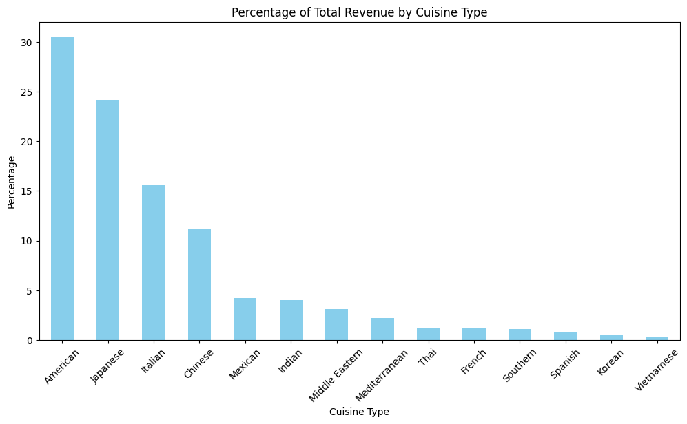

```
High-Cost Group (cost_of_order > 20) by Cuisine:
Profit Amount:
cuisine_type
American          1126.9900
Chinese            412.2750
French              56.8725
Indian             154.3075
Italian            582.4225
Japanese           829.0175
Korean              15.0000
Mediterranean       73.8800
Mexican            154.6075
Middle Eastern     138.0550
Southern            48.8425
Spanish             32.6175
Thai                58.2750
Vietnamese           5.5650
Name: revenue, dtype: float64

Percentage of Profit:
cuisine_type
American          30.552270
Chinese           11.176618
French             1.541792
Indian             4.183218
Italian           15.789253
Japanese          22.474349
Korean             0.406644
Mediterranean      2.002859
Mexican            4.191351
Middle Eastern     3.742619
Southern           1.324102
Spanish            0.884248
Thai               1.579813
Vietnamese         0.150865
Name: revenue, dtype: float64

Medium-Cost Group (cost_of_order > 5 and <= 20) by Cuisine:
Profit Amount:
cuisine_type
```

[output cut: 18 more lines]

```
American          30.323354
Chinese           11.211182
French             0.779795
Indian             3.741016
Italian           15.517670
Japanese          26.204126
Korean             0.738746
Mediterranean      2.520529
Mexican            4.120379
Middle Eastern     2.240033
Southern           0.803649
Spanish            0.590053
Thai               0.798260
Vietnamese         0.411208
Name: revenue, dtype: float64
```

```python
# Calculate the revenue generated for each order based on fees
def calculate_revenue(row):
    if row['cost_of_the_order'] > 20:
        return row['cost_of_the_order'] * 0.25  # 25% fee
    elif row['cost_of_the_order'] > 5:
        return row['cost_of_the_order'] * 0.15  # 15% fee
    else:
        return row['cost_of_the_order']  # No fee

# Apply the calculate_revenue function to each row to calculate revenue
df['revenue'] = df.apply(calculate_revenue, axis=1)

# Calculate the net revenue by summing up the revenue column
net_revenue = df['revenue'].sum()

# Calculate revenue by cuisine type
revenue_by_cuisine = df.groupby('cuisine_type')['revenue'].sum()

# Calculate the percentage of total revenue provided by each cuisine
percentage_of_total_revenue = (revenue_by_cuisine / net_revenue) * 100

# Format revenue as currency
revenue_by_cuisine = revenue_by_cuisine.map('${:,.2f}'.format)

# Add the percentage to the DataFrame
revenue_by_cuisine = revenue_by_cuisine + " (" + percentage_of_total_revenue.map('{:.2f}%'.format).astype(str) + ")"

# Print the net revenue generated by the company
print(f"Net revenue generated by the company across all orders: ${net_revenue:.2f}")

# Print revenue generated by cuisine type with percentage
print("\nRevenue generated by cuisine type (Percentage of Total Revenue):")
print(revenue_by_cuisine)

# Convert the percentage_of_total_revenue Series to numeric
percentage_of_total_revenue = percentage_of_total_revenue.astype(float)

# Create a bar chart
plt.figure(figsize=(12, 6))
percentage_of_total_revenue.sort_values(ascending=False).plot(kind='bar', color='skyblue')
plt.title('Percentage of Total Revenue by Cuisine Type')
plt.ylabel('Percentage')
plt.xlabel('Cuisine Type')
plt.xticks(rotation=45)
plt.show()

# Convert 'cost_of_the_order' column to numeric, replacing any non-numeric values with NaN
df['cost_of_the_order'] = pd.to_numeric(df['cost_of_the_order'], errors='coerce')

# Create two conditions for categorizing orders
condition_1 = (df['cost_of_the_order'] > 20)
condition_2 = (df['cost_of_the_order'] > 5) & (df['cost_of_the_order'] <= 20)

# Calculate the profit generated by orders that meet condition 1 (using 'revenue' column)
profit_high_cost = df[condition_1].groupby('cuisine_type')['revenue'].sum()

# Calculate the total profit generated by high-cost orders
total_profit_high_cost = profit_high_cost.sum()

# Calculate the profit generated by orders that meet condition 2 (using 'revenue' column)
profit_medium_cost = df[condition_2].groupby('cuisine_type')['revenue'].sum()

# Calculate the total profit generated by medium-cost orders
total_profit_medium_cost = profit_medium_cost.sum()

# Calculate the percentage of profit for each cuisine in the high-cost group
percentage_profit_high_cost = (profit_high_cost / total_profit_high_cost) * 100

# Calculate the percentage of profit for each cuisine in the medium-cost group
percentage_profit_medium_cost = (profit_medium_cost / total_profit_medium_cost) * 100

# Print both the profit and percentage of profit for both categories by cuisine
print("High-Cost Group (cost_of_order > 20) by Cuisine:")
print("Profit Amount:")
print(profit_high_cost)
print("\nPercentage of Profit:")
print(percentage_profit_high_cost)

print("\nMedium-Cost Group (cost_of_order > 5 and <= 20) by Cuisine:")
print("Profit Amount:")
print(profit_medium_cost)
print("\nPercentage of Profit:")
print(percentage_profit_medium_cost)
```

#### Observations:

The cuisine that provided the most revenue for the company was American with $1,892.53 and (30.48%) of the total revenue generated based on fees of the cost_of_the_order.

### **Question 15:** The company wants to analyze the total time required to deliver the food. What percentage of orders take more than 60 minutes to get delivered from the time the order is placed? (The food has to be prepared and then delivered.) [2 marks]

```python
# Convert 'food_preparation_time' and 'delivery_time' columns to numeric, replacing any non-numeric values with NaN
df['food_preparation_time'] = pd.to_numeric(df['food_preparation_time'], errors='coerce')
df['delivery_time'] = pd.to_numeric(df['delivery_time'], errors='coerce')

# Calculate the total time for each order
df['total_delivery_time'] = df['food_preparation_time'] + df['delivery_time']

# Calculate mean, max, min, and median of total delivery time
mean_delivery_time = df['total_delivery_time'].mean()
max_delivery_time = df['total_delivery_time'].max()
min_delivery_time = df['total_delivery_time'].min()
median_delivery_time = df['total_delivery_time'].median()

# Calculate the count of orders that took more than 60 minutes
orders_over_60_minutes = (df['total_delivery_time'] > 60).sum()

# Calculate the percentage of orders that took more than 60 minutes
total_orders = len(df)
percentage_over_60_minutes = (orders_over_60_minutes / total_orders) * 100

# Print the statistics
print(f"Mean Total Delivery Time: {mean_delivery_time:.2f} minutes")
print(f"Max Total Delivery Time: {max_delivery_time:.2f} minutes")
print(f"Min Total Delivery Time: {min_delivery_time:.2f} minutes")
print(f"Median Total Delivery Time: {median_delivery_time:.2f} minutes")
print(f"Count of Orders Taking More than 60 Minutes: {orders_over_60_minutes}")
print(f"Percentage of Orders Taking More than 60 Minutes: {percentage_over_60_minutes:.2f}%")
```

```
Mean Total Delivery Time: 51.53 minutes
Max Total Delivery Time: 68.00 minutes
Min Total Delivery Time: 35.00 minutes
Median Total Delivery Time: 52.00 minutes
Count of Orders Taking More than 60 Minutes: 200
Percentage of Orders Taking More than 60 Minutes: 10.54%
```

#### Observations:

There were 200 orders that took more than 60 minutes to get delivered. That is 10.54% of the total orders.

### **Question 16:** The company wants to analyze the delivery time of the orders on weekdays and weekends. How does the mean delivery time vary during weekdays and weekends? [2 marks]

```python
# Convert 'delivery_time' column to numeric, replacing any non-numeric values with NaN
df['delivery_time'] = pd.to_numeric(df['delivery_time'], errors='coerce')

# Calculate the mean delivery time for weekdays and weekends
mean_delivery_time_by_day = df.groupby('day_of_the_week')['delivery_time'].mean()

# Print the mean delivery time for weekdays and weekends
print(mean_delivery_time_by_day)
```

```
day_of_the_week
Weekday    28.340037
Weekend    22.470022
Name: delivery_time, dtype: float64
```

#### Observations:

It appears that delivery time on average is greater during a weekday with an average time of 28.34 minutes versus on the weekend with a shorter average delivery time of 22.47 minutes.

### Conclusion and Recommendations

### **Question 17:** What are your conclusions from the analysis? What recommendations would you like to share to help improve the business? (You can use cuisine type and feedback ratings to drive your business recommendations.) [6 marks]

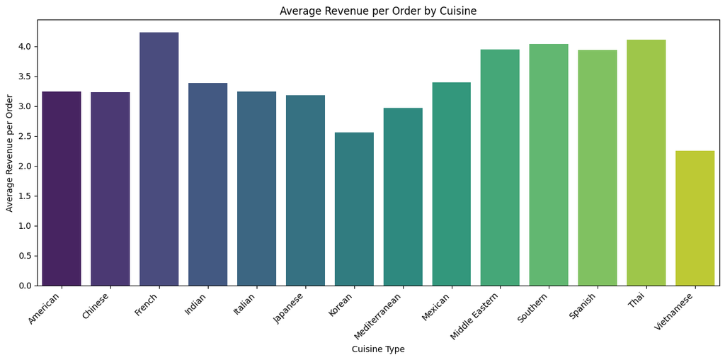

```python
# Convert 'revenue' column to numeric, replacing any non-numeric values with NaN
df['revenue'] = pd.to_numeric(df['revenue'], errors='coerce')

# Calculate the average revenue per order by cuisine
average_revenue_by_cuisine = df.groupby('cuisine_type')['revenue'].mean()

# Create a bar plot to visualize the average revenue by cuisine
plt.figure(figsize=(12, 6))
sns.barplot(x=average_revenue_by_cuisine.index, y=average_revenue_by_cuisine.values, palette='viridis')
plt.xticks(rotation=45, ha='right')
plt.xlabel('Cuisine Type')
plt.ylabel('Average Revenue per Order')
plt.title('Average Revenue per Order by Cuisine')
plt.tight_layout()

# Display the bar plot
plt.show()
```

### Recommendations:

My recommendation would be to attempt an increase in order volumes of French, Thai, and Southern cuisine restaurants to customers of the food ordering platform.

The reasoning behind this is these three cuisines have higher average revenue per order, but the count of orders from these cuisines are low.

The promotion would be a possible discount like 5% of there total order, cutting into the revenue of the order for the platform, but this is potentially ok, as the average revenue per order is so high.

There are potential downsides to this recommendation however, since the current data available on these cuisines are low, it would be important to monitor the incoming data of these cuisines to make sure the promotional discount does not cause a net loss in revenue margins.